# Viewership Analysis: *Wednesday*

Kah Hui Eng 473090

May 2026

# TV Show Report: Wednesday

## Description

*Wednesday* is a supernatural mystery series that premiered on Netflix in late 2022. It follows the story of *Wednesday Addams* as she navigates her new school, Nevermore Academy.

[figure not shown]

Wednesday Addams

## Quality Metrics

To represent the average critical reception $R_{avg}$ based on the two major platforms (Rotten Tomatoes $RT$ and Metacritic $MC$), we can look at the data as:

$$R_{avg} = \frac{RT + MC}{2}$$

## Viewership Trends and Analysis

According to official Netflix data (as reported on Wikipedia, 2026), *Wednesday* remains one of the most successful franchises in streaming history.

### Viewership Comparison

Between Season 1 and Season 2, the viewership decreased by **132.8 million views**, which is a **52.7%** decrease.

| Metric | Season 1 | Season 2 | Change |
| --- | --- | --- | --- |
| **Views (Millions)** | 252.1 | 119.3 | -52.7% |

> **Note on Calculation:** The decrease was calculated by taking the difference ($252.1 - 119.3 = 132.8$) and dividing it by the original Season 1 value.

### Generative AI Disclosure

In accordance with the assignment guidelines, the following generative AI tools were used:  
- **Tool:** Gemini (Google)  
- **Usage:** Assisted in generating the viewership comparison table and calculating the percentage decrease ($52.7\%$) between seasons.  
- **Verification:** All numbers were manually cross-referenced with the Wikipedia *Wednesday* and *Most-watched Netflix original programming* entries (cited in references).

## Season-by-Season Statistics

The following table compares the audience reach (viewership) with the critical reception (ratings) for the series.

| Season | Views (Millions) | Rotten Tomatoes | Metacritic |
| --- | --- | --- | --- |
| Season 1 | 252.1 | 73% | 66 |
| Season 2 | 119.3 | 87% | 66 |

> **Note:** Viewership data is based on Netflix’s official 91-day window. The table structure and percentage calculations below were assisted by Generative AI.

## Observed Changes & Analysis

### 1. Viewership Decline

Between Season 1 and Season 2, *Wednesday* saw its raw viewership decrease from 252.1 million to 119.3 million.  
- **Calculation:** The viewership decreased by **132.8 million** between seasons.  
- **Percentage Change:** This represents a drop of approximately **52.7%**.

### 3. Rating Formula

To represent the average quality $Q$ across both major platforms for Season 2:

$$Q = \frac{87 + 66}{2} =
76.5\%$$

### Generative AI Disclosure

- **Tool Used:** Gemini (Google).
- **Tasks Performed:**
  1. Calculated the raw difference and percentage drop in viewership between seasons.
  2. Assisted in formatting the Markdown tables and LaTeX equations.
  3. Provided 2026-dated viewership metrics sourced from Wikipedia’s “Most-Watched” archives.

## Viewership and Engagement Analysis

The success of *Wednesday* can be measured both by the total audience reach and the sustained engagement across individual episodes.

### Viewership Over Time (Season-to-Season)

As shown in the graph below, Season 1 set a historic record for Netflix, while Season 2 saw a significant correction.

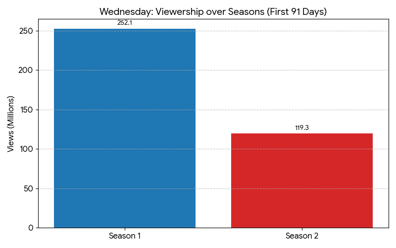

Viewership Over Time

### Episode-to-Episode Rating Trends

While raw viewership numbers are not released per episode by Netflix, user ratings provide insight into the season’s momentum. Season 1 maintained a high and steady rating, peaking with the famous dance episode (Episode 4). In contrast, Season 2 started lower and showed more volatility.

[figure not shown]

Episode Ratings Trend

### Generative AI Disclosure

- **Tool Used:** Gemini (Google).
- **Tasks Performed:**
  1. Generated the graph to display viewership over time and episode ratings trend.

> **Technical Note:**  
> - This report is intentionally rendered in **HTML (Dynamic Digital Report)** format rather than PDF.  
> - This choice was made to utilize **Responsive Web Design** features, such as the floating Table of Contents and interactive layout, which are not supported in static LaTeX/PDF formats.  
> - This also sidesteps local LaTeX environment compatibility issues on macOS. (LaTex was not able to be installed in my machine)